# customersegmentation

### EDA

#### Univariate analysis

```python
# function to plot a boxplot and a histogram along the same scale.


def histogram_boxplot(data, feature, figsize=(12, 7), kde=False, bins=None):
    """
    Boxplot and histogram combined

    data: dataframe
    feature: dataframe column
    figsize: size of figure (default (12,7))
    kde: whether to the show density curve (default False)
    bins: number of bins for histogram (default None)
    """
    f2, (ax_box2, ax_hist2) = plt.subplots(
        nrows=2,  # Number of rows of the subplot grid= 2
        sharex=True,  # x-axis will be shared among all subplots
        gridspec_kw={"height_ratios": (0.25, 0.75)},
        figsize=figsize,
    )  # creating the 2 subplots
    sns.boxplot(
        data=data, x=feature, ax=ax_box2, showmeans=True, color="violet"
    )  # boxplot will be created and a star will indicate the mean value of the column
    sns.histplot(
        data=data, x=feature, kde=kde, ax=ax_hist2, bins=bins, palette="winter"
    ) if bins else sns.histplot(
        data=data, x=feature, kde=kde, ax=ax_hist2
    )  # For histogram
    ax_hist2.axvline(
        data[feature].mean(), color="green", linestyle="--"
    )  # Add mean to the histogram
    ax_hist2.axvline(
        data[feature].median(), color="black", linestyle="-"
    )  # Add median to the histogram
```

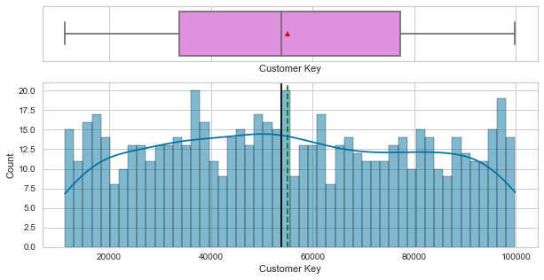

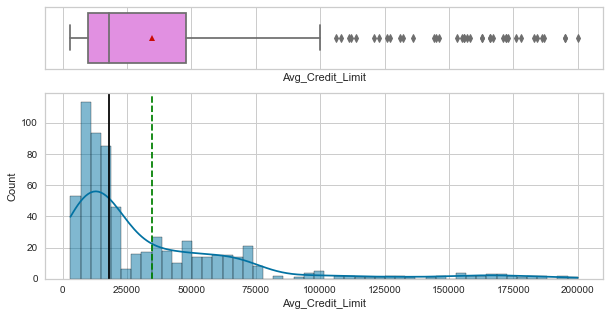

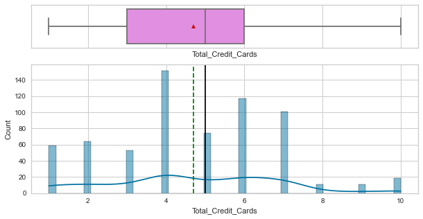

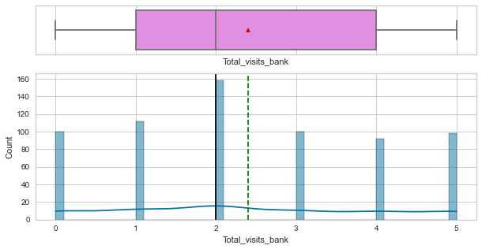

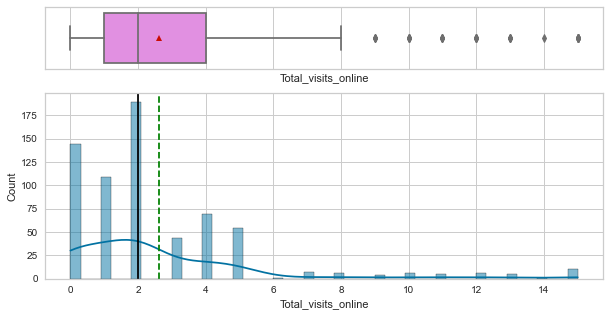

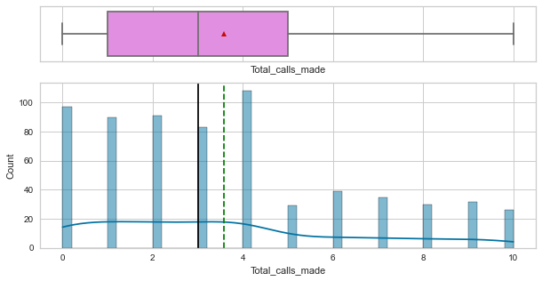

```python
# selecting numerical columns
num_cols = data.select_dtypes(include=np.number).columns.tolist()

for item in num_cols:
    histogram_boxplot(data, item, bins=50, kde=True, figsize=(10, 5))
```

### Observations

#### Bivariate Analysis

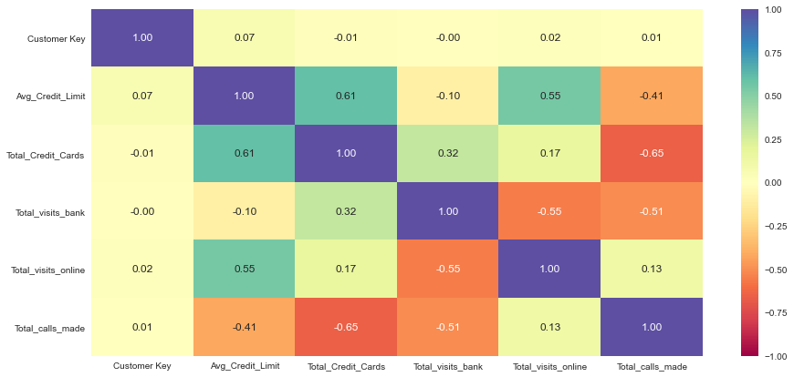

```python
plt.figure(figsize=(15, 7))
sns.heatmap(
    data[num_cols].corr(), annot=True, vmin=-1, vmax=1, fmt=".2f", cmap="Spectral"
)
plt.show()
```

### Observation

- Avg_credit_Limit is highly correlated with total creditcards.

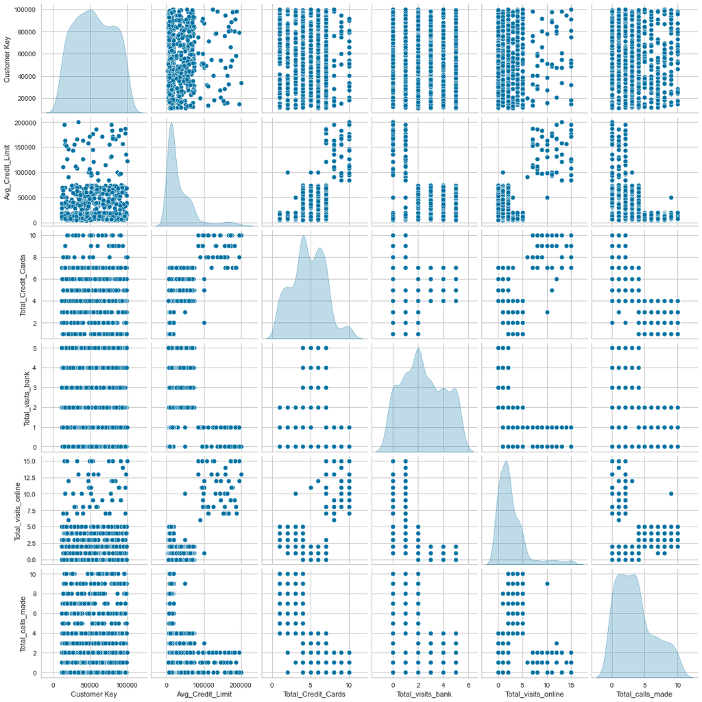

```python
sns.pairplot(data, diag_kind="kde")
plt.show()
```

### Datapreprocessing

```python
# Checking null values
data.isnull().sum()
```

```
Customer Key           0
Avg_Credit_Limit       0
Total_Credit_Cards     0
Total_visits_bank      0
Total_visits_online    0
Total_calls_made       0
dtype: int64
```

- No missing values in data

### Finding outliers

```python
Q1 = data.quantile(0.25)  # To find the 25th percentile and 75th percentile.
Q3 = data.quantile(0.75)

IQR = Q3 - Q1  # Inter Quantile Range (75th perentile - 25th percentile)

lower = (
    Q1 - 1.5 * IQR
)  # Finding lower and upper bounds for all values. All values outside these bounds are outliers
upper = Q3 + 1.5 * IQR
```

```python
(
    (data.select_dtypes(include=["int64"]) < lower)
    | (data.select_dtypes(include=["int64"]) > upper)
).sum() / len(data) * 100
```

```
Customer Key           0.000000
Avg_Credit_Limit       5.909091
Total_Credit_Cards     0.000000
Total_visits_bank      0.000000
Total_visits_online    5.606061
Total_calls_made       0.000000
dtype: float64
```

- After identifying outliers, we can decide whether to remove/treat them or not. It depends on one's approach, here we are not going to treat them as there will be outliers in real case scenario. we would want our model to learn the underlying pattern for such customers.

```python
# Checking for duplicates
data.duplicated().sum()
```

```
0
```

- No duplicate values in data.

```python
# Scaling the data set before clustering
scaler = StandardScaler()
data1 = data.copy()
data_scaled = scaler.fit_transform(data1)
```

```python
# Creating a dataframe from the scaled data
data_scaled_df = pd.DataFrame(data_scaled, columns=data1.columns)
```

```
Number of Clusters: 1 	Average Distortion: 2.2569539857353345
Number of Clusters: 2 	Average Distortion: 1.7858322163326599
Number of Clusters: 3 	Average Distortion: 1.505531485649799
Number of Clusters: 4 	Average Distortion: 1.363222352950455
Number of Clusters: 5 	Average Distortion: 1.272651786882213
Number of Clusters: 6 	Average Distortion: 1.219426630337813
Number of Clusters: 7 	Average Distortion: 1.1796925222091639
Number of Clusters: 8 	Average Distortion: 1.1451767813291247
```

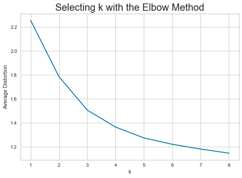

```python
clusters = range(1, 9)
meanDistortions = []

for k in clusters:
    model = KMeans(n_clusters=k)
    model.fit(data_scaled_df)
    prediction = model.predict(data_scaled_df)
    distortion = (
        sum(np.min(cdist(data_scaled_df, model.cluster_centers_, "euclidean"), axis=1))
        / data_scaled_df.shape[0]
    )

    meanDistortions.append(distortion)

    print("Number of Clusters:", k, "\tAverage Distortion:", distortion)

plt.plot(clusters, meanDistortions, "bx-")
plt.xlabel("k")
plt.ylabel("Average Distortion")
plt.title("Selecting k with the Elbow Method", fontsize=20)
```

- The appropriate value of k from the elbow curve seems to be 4 or 5.

##### Let's check the silhouette scores

```
For n_clusters = 2, silhouette score is 0.33817196365464486
For n_clusters = 3, silhouette score is 0.4177434852377372
For n_clusters = 4, silhouette score is 0.3228907072652812
For n_clusters = 5, silhouette score is 0.2850863954249504
For n_clusters = 6, silhouette score is 0.25413205265109257
For n_clusters = 7, silhouette score is 0.2379857898045632
For n_clusters = 8, silhouette score is 0.22812339023436642
For n_clusters = 9, silhouette score is 0.20827545889105914
```

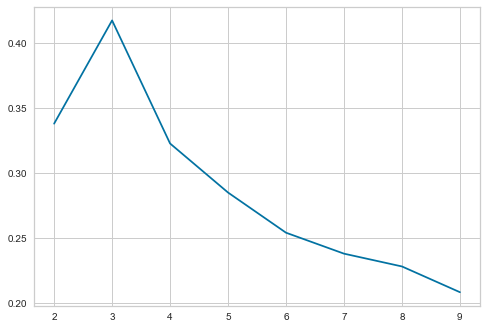

```python
sil_score = []
cluster_list = list(range(2, 10))
for n_clusters in cluster_list:
    clusterer = KMeans(n_clusters=n_clusters)
    preds = clusterer.fit_predict((data_scaled_df))
    # centers = clusterer.cluster_centers_
    score = silhouette_score(data_scaled_df, preds)
    sil_score.append(score)
    print("For n_clusters = {}, silhouette score is {}".format(n_clusters, score))

plt.plot(cluster_list, sil_score)
```

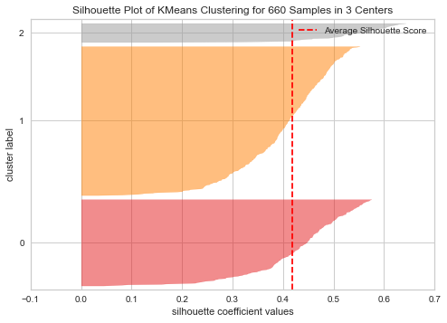

```python
# finding optimal no. of clusters with silhouette coefficients
visualizer = SilhouetteVisualizer(KMeans(3, random_state=1))
visualizer.fit(data_scaled_df)
visualizer.show()
```

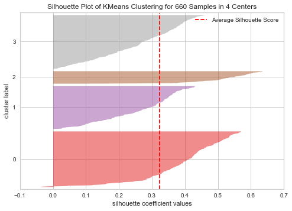

```python
# finding optimal no. of clusters with silhouette coefficients
visualizer = SilhouetteVisualizer(KMeans(4, random_state=1))
visualizer.fit(data_scaled_df)
visualizer.show()
```

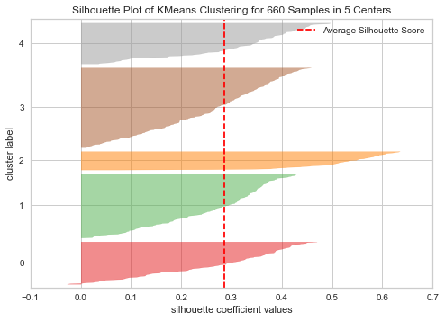

```python
# finding optimal no. of clusters with silhouette coefficients
visualizer = SilhouetteVisualizer(KMeans(5, random_state=1))
visualizer.fit(data_scaled_df)
visualizer.show()
```

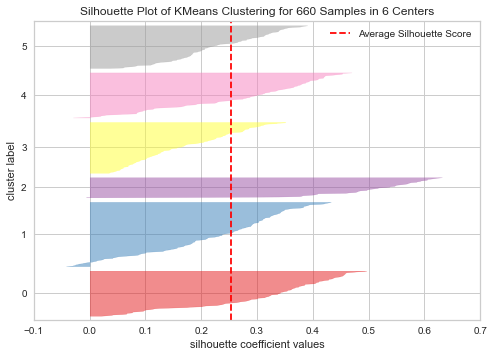

```python
# finding optimal no. of clusters with silhouette coefficients
visualizer = SilhouetteVisualizer(KMeans(6, random_state=1))
visualizer.fit(data_scaled_df)
visualizer.show()
```

- It seems 4 as the appropriate clusters
- The Silhouette coefficient is high enough for 4 clusters

```python
kmeans = KMeans(n_clusters=4, random_state=0)
kmeans.fit(data_scaled_df)
```

```
KMeans(n_clusters=4, random_state=0)
```

```python
# adding kmeans cluster labels to the original dataframe
data_scaled_df["K_means_segments"] = kmeans.labels_
data1["K_means_segments"] = kmeans.labels_
```

```python
kmeans_cluster_profile = data1.groupby("K_means_segments").mean()
```

```python
kmeans_cluster_profile["count_in_each_segments"] = (
    data_scaled_df.groupby("K_means_segments")["Avg_Credit_Limit"].count().values
)
```

```python
# let's display cluster profiles
kmeans_cluster_profile.style.highlight_max(color="lightgreen", axis=0)
```

| K_means_segments | Customer Key | Avg_Credit_Limit | Total_Credit_Cards | Total_visits_bank | Total_visits_online | Total_calls_made | count_in_each_segments |
| --- | --- | --- | --- | --- | --- | --- | --- |
| 0 | 79136.872093 | 37651.162791 | 5.593023 | 3.523256 | 0.941860 | 1.936047 | 172 |
| 1 | 35299.195349 | 30618.604651 | 5.446512 | 3.455814 | 1.027907 | 2.060465 | 215 |
| 2 | 55412.762332 | 12143.497758 | 2.403587 | 0.928251 | 3.551570 | 6.883408 | 223 |
| 3 | 56708.760000 | 141040.000000 | 8.740000 | 0.600000 | 10.900000 | 1.080000 | 50 |

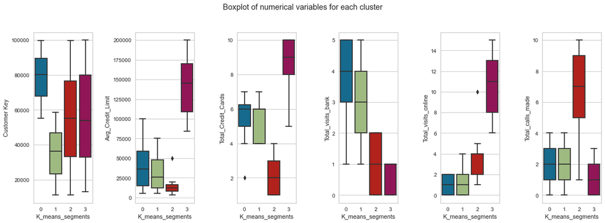

```python
fig, axes = plt.subplots(1, 6, figsize=(16, 6))
fig.suptitle("Boxplot of numerical variables for each cluster")
counter = 0
for ii in range(6):
    sns.boxplot(
        ax=axes[ii],
        y=data[num_cols[counter]],
        x=data_scaled_df["K_means_segments"],
    )
    counter = counter + 1

fig.tight_layout(pad=2.0)
```

#### Insights

##### Cluster 0:

```
   * The Avg_Credit_Limit is close to 37000
   * The Avg total credit cards are 6.
   * The Maximum number of visits to the bank 5 and minimum is 1
   * The minimum visits online is 0 and the Maximum is 2. It looks customers are not intrested for online banking.
   * The avg phone calls are 2.
```

##### Cluster 1:

[output not shown]

##### Cluster 2:

[output not shown]

##### Cluster 3:

[output not shown]

### Hierarchical Clustering

```python
# list of distance metrics
distance_metrics = ["euclidean", "chebyshev", "mahalanobis", "cityblock"]

# list of linkage methods
linkage_methods = ["single", "complete", "average", "weighted"]

high_cophenet_corr = 0
high_dm_lm = [0, 0]

for dm in distance_metrics:
    for lm in linkage_methods:
        Z = linkage(data_scaled_df, metric=dm, method=lm)
        c, coph_dists = cophenet(Z, pdist(data_scaled_df))
        print(
            "Cophenetic correlation for {} distance and {} linkage is {}.".format(
                dm.capitalize(), lm, c
            )
        )
        if high_cophenet_corr < c:
            high_cophenet_corr = c
            high_dm_lm[0] = dm
            high_dm_lm[1] = lm
```

```
Cophenetic correlation for Euclidean distance and single linkage is 0.8207339090039346.
Cophenetic correlation for Euclidean distance and complete linkage is 0.8760633606188161.
Cophenetic correlation for Euclidean distance and average linkage is 0.8970847775744214.
Cophenetic correlation for Euclidean distance and weighted linkage is 0.8817961834774709.
Cophenetic correlation for Chebyshev distance and single linkage is 0.8386111592294128.
Cophenetic correlation for Chebyshev distance and complete linkage is 0.813417302701346.
Cophenetic correlation for Chebyshev distance and average linkage is 0.889965753413227.
Cophenetic correlation for Chebyshev distance and weighted linkage is 0.8845062419837355.
Cophenetic correlation for Mahalanobis distance and single linkage is 0.7514204626863494.
Cophenetic correlation for Mahalanobis distance and complete linkage is 0.6416947173755392.
Cophenetic correlation for Mahalanobis distance and average linkage is 0.8213459368893982.
Cophenetic correlation for Mahalanobis distance and weighted linkage is 0.7570542714054904.
Cophenetic correlation for Cityblock distance and single linkage is 0.824750698477764.
Cophenetic correlation for Cityblock distance and complete linkage is 0.8697184272228192.
Cophenetic correlation for Cityblock distance and average linkage is 0.894188933068535.
Cophenetic correlation for Cityblock distance and weighted linkage is 0.8463183710220061.
```

```python
# printing the combination of distance metric and linkage method with the highest cophenetic correlation
print(
    "Highest cophenetic correlation is {}, which is obtained with {} distance and {} linkage.".format(
        high_cophenet_corr, high_dm_lm[0].capitalize(), high_dm_lm[1]
    )
)
```

```
Highest cophenetic correlation is 0.8970847775744214, which is obtained with Euclidean distance and average linkage.
```

```python
# list of linkage methods
linkage_methods = ["single", "complete", "average", "centroid", "ward", "weighted"]

high_cophenet_corr = 0
high_dm_lm = [0, 0]

for lm in linkage_methods:
    Z = linkage(data_scaled_df, metric="euclidean", method=lm)
    c, coph_dists = cophenet(Z, pdist(data_scaled_df))
    print("Cophenetic correlation for {} linkage is {}.".format(lm, c))
    if high_cophenet_corr < c:
        high_cophenet_corr = c
        high_dm_lm[0] = "euclidean"
        high_dm_lm[1] = lm
```

```
Cophenetic correlation for single linkage is 0.8207339090039346.
Cophenetic correlation for complete linkage is 0.8760633606188161.
Cophenetic correlation for average linkage is 0.8970847775744214.
Cophenetic correlation for centroid linkage is 0.8955499219561204.
Cophenetic correlation for ward linkage is 0.753618496931061.
Cophenetic correlation for weighted linkage is 0.8817961834774709.
```

```python
# printing the combination of distance metric and linkage method with the highest cophenetic correlation
print(
    "Highest cophenetic correlation is {}, which is obtained with {} linkage.".format(
        high_cophenet_corr, high_dm_lm[1]
    )
)
```

```
Highest cophenetic correlation is 0.8970847775744214, which is obtained with average linkage.
```

- We see that the cophenetic correlation is maximum with Euclidean distance and average linkage.

#### Dendrograms for the different linkage methods

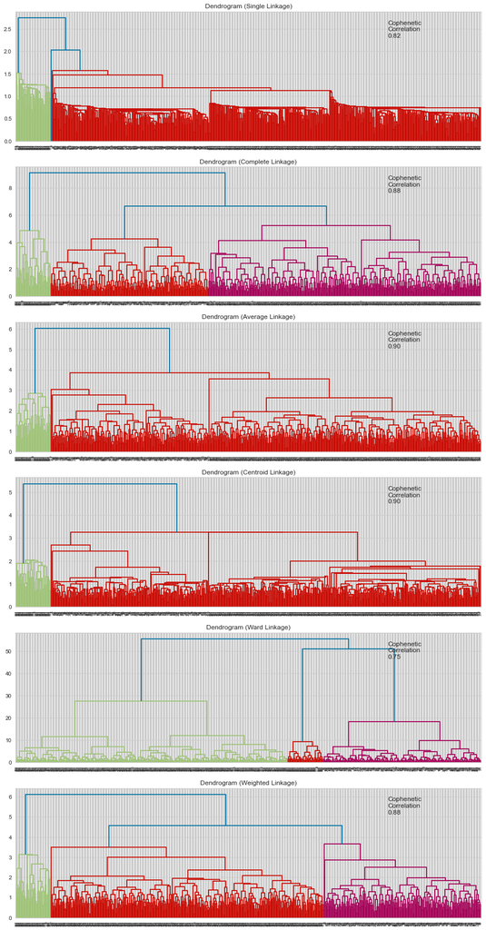

```python
# list of linkage methods
linkage_methods = ["single", "complete", "average", "centroid", "ward", "weighted"]

# lists to save results of cophenetic correlation calculation
compare_cols = ["Linkage", "Cophenetic Coefficient"]

# to create a subplot image
fig, axs = plt.subplots(len(linkage_methods), 1, figsize=(15, 30))

# We will enumerate through the list of linkage methods above
# For each linkage method, we will plot the dendrogram and calculate the cophenetic correlation
for i, method in enumerate(linkage_methods):
    Z = linkage(data_scaled_df, metric="euclidean", method=method)

    dendrogram(Z, ax=axs[i])
    axs[i].set_title(f"Dendrogram ({method.capitalize()} Linkage)")

    coph_corr, coph_dist = cophenet(Z, pdist(data_scaled_df))
    axs[i].annotate(
        f"Cophenetic\nCorrelation\n{coph_corr:0.2f}",
        (0.80, 0.80),
        xycoords="axes fraction",
    )
```

#### Observations

```python
HCmodel = AgglomerativeClustering(n_clusters=4, affinity="euclidean", linkage="average")
HCmodel.fit(data_scaled_df)
```

```
AgglomerativeClustering(linkage='average', n_clusters=4)
```

```python
data_scaled_df["HCA_Clusters"] = HCmodel.labels_
data1["HCA_Clusters"] = HCmodel.labels_
```

### Cluster Profiling

```python
# grouping HC clusters by mean
avg_cluster_profile = data1.groupby("HCA_Clusters").mean()
```

```python
# adding a new column to the cluster profile by counting number of values in each cluster
avg_cluster_profile["count_in_each_segments"] = (
    data1.groupby("HCA_Clusters")["Avg_Credit_Limit"].count().values
)
```

#### let's see the Customer Key in each cluster

```python
# displaying customer keys in each cluster
for cl in data1["HCA_Clusters"].unique():
    print("In cluster {}, the following Customer Keys are present:".format(cl))
    print(data1[data1["HCA_Clusters"] == cl]["Customer Key"].unique())
    print()
```

```
In cluster 3, the following Customer Keys are present:
[87073]

In cluster 0, the following Customer Keys are present:
[38414 58634 37376 82490 44770 52741 52326 92503 25084 68517 55196 62617
 96463 39137 14309 29794 87241 30507 61061 24001 68067 65034 14854 81130
 29112 13999 32550 82164 61517 28254 30888 46388 74126 52142 37659 83132
 20119 52363 50769 68502 99026 83326 62040 37252 74625 51182 60301 96386
 43886 78503 68419 32828 17937 71632 81566 29759 36929 70248 91673 61355
 60403 85868 76205 66524 69214 21976 35149 27120 18821 33187 93482 90168
 71881 59656 12026 99589 38970 57990 39447 79694 79403 47296 37559 38165
 49198 18007 59619 37016 91099 74704 25742 11937 52736 88338 18916 92501
 96213 26599 73007 97935 26089 14946 74795 73435 41634 84069 83244 87291
 18086 33369 15310 98499 35256 89007 93997 16577 25440 81116 63663 69811
 36111 39454 70199 11602 49697 28701 61627 34103 14248 31256 45583 52750
```

[output cut: 49 more lines]

### Observations

```python
HCmodel = AgglomerativeClustering(n_clusters=4, affinity="euclidean", linkage="ward")
HCmodel.fit(data_scaled_df)
```

```
AgglomerativeClustering(n_clusters=4)
```

```python
data_scaled_df["HCW_Clusters"] = HCmodel.labels_
data1["HCW_Clusters"] = HCmodel.labels_
```

#### Cluster profiling

```python
ward_cluster_profile = data1.groupby("HCW_Clusters").mean()
```

```python
ward_cluster_profile["count_in_each_segments"] = (
    data1.groupby("HCW_Clusters")["Avg_Credit_Limit"].count().values
)
```

#### let's see the Customer Key in each cluster

```python
# let's see the Customer keys in each cluster
for cl in data1["HCW_Clusters"].unique():
    print(
        "The",
        data1[data1["HCW_Clusters"] == cl]["Customer Key"].nunique(),
        "Customer Keys in cluster",
        cl,
        "are:",
    )
    print(data1[data1["HCW_Clusters"] == cl]["Customer Key"].unique())
    print("-" * 100, "\n")
```

```
The 171 Customer Keys in cluster 3 are:
[87073 97825 83125 83290 81878 85799 81531 69965 65372 89328 71402 67193
 97109 66504 95925 74544 73952 77026 75775 94666 95610 85337 67911 92956
 77641 78002 83459 91987 87485 81863 92782 64672 62483 85614 96548 69028
 70779 67046 64897 77381 81940 66706 87838 94437 66804 61996 89635 71681
 71862 96186 88807 82376 98126 80347 62807 92522 61994 72431 85122 65574
 96929 78912 68439 62864 77954 88207 78618 75792 97954 90189 55090 88884
 92140 88123 65908 87456 97530 76209 61122 82807 93496 64519 96297 58019
 87219 60851 65747 81166 70707 84351 89446 64774 94595 92489 92933 70101
 77613 84360 67258 65781 62649 74446 76024 75065 56367 95147 76957 61324
 62530 65825 77826 61216 83192 82023 73000 64550 90131 94529 81910 76492
 99131 99437 91242 63710 90860 69868 83585 68040 75417 85645 83545 75398
 90999 70376 80942 97850 79885 59316 83466 81510 88411 96269 87683 58116
 67282 84888 75366 59074 96534 68920 67637 60839 59170 90586 87670 58511
 76398 93310 94700 67860 99473 68862 93381 74083 72339 99284 67415 58276
```

[output cut: 53 more lines]

```python
# lets display cluster profile
ward_cluster_profile.style.highlight_max(color="lightgreen", axis=0)
```

| HCW_Clusters | Customer Key | Avg_Credit_Limit | Total_Credit_Cards | Total_visits_bank | Total_visits_online | Total_calls_made | K_means_segments | HCA_Clusters | count_in_each_segments |
| --- | --- | --- | --- | --- | --- | --- | --- | --- | --- |
| 0 | 55239.830357 | 12174.107143 | 2.410714 | 0.933036 | 3.553571 | 6.870536 | 1.995536 | 0.000000 | 224 |
| 1 | 35386.219626 | 30672.897196 | 5.453271 | 3.462617 | 1.014019 | 2.051402 | 1.000000 | 2.000000 | 214 |
| 2 | 56708.760000 | 141040.000000 | 8.740000 | 0.600000 | 10.900000 | 1.080000 | 3.000000 | 1.000000 | 50 |
| 3 | 79136.872093 | 37651.162791 | 5.593023 | 3.523256 | 0.941860 | 1.936047 | 0.000000 | 2.005814 | 172 |

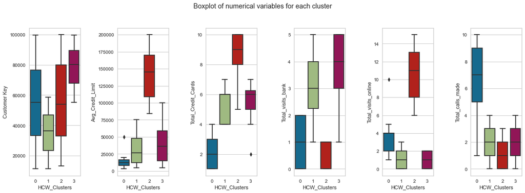

```python
# Function to display boxplots for each cluster
fig, axes = plt.subplots(1, 6, figsize=(16, 6))
fig.suptitle("Boxplot of numerical variables for each cluster")
counter = 0
for ii in range(6):
    sns.boxplot(
        ax=axes[ii],
        y=data[num_cols[counter]],
        x=data_scaled_df["HCW_Clusters"],
    )
    counter = counter + 1

fig.tight_layout(pad=2.0)
```

### Insights

##### Cluster 0:

[output not shown]

##### Cluster 1:

[output not shown]

##### Cluster 2:

[output not shown]

##### Cluster 3:

[output not shown]

### Comparing K-means and Hierarchical clustering

```python
ward_cluster_profile.drop(["K_means_segments", "HCA_Clusters"], axis=1, inplace=True)
avg_cluster_profile.drop(["K_means_segments"], axis=1, inplace=True)
```

```python
# comparison of different clusters
compare_cluster_df = pd.concat(
    [ward_cluster_profile, avg_cluster_profile, kmeans_cluster_profile], axis=0
)
Cluster_Names = [
    "Ward_HC0",
    "Ward_HC1",
    "Ward_HC2",
    "Ward_HC3",
    "Avg_HC0",
    "Avg_HC1",
    "Avg_HC2",
    "Avg_HC3",
    "Kmeans_C0",
    "Kmeans_C1",
    "Kmeans_C2",
    "Kmeans_C3",
]
compare_cluster_df["Cluster_Name"] = Cluster_Names
compare_cluster_df = compare_cluster_df.reindex(
    columns=(
        ["Cluster_Name"]
        + list([a for a in compare_cluster_df.columns if a != "Cluster_Name"])
    )
)
compare_cluster_df
```

|  | Cluster_Name | Customer Key | Avg_Credit_Limit | Total_Credit_Cards | Total_visits_bank | Total_visits_online | Total_calls_made | count_in_each_segments |
| --- | --- | --- | --- | --- | --- | --- | --- | --- |
| 0 | Ward_HC0 | 55239.830357 | 12174.107143 | 2.410714 | 0.933036 | 3.553571 | 6.870536 | 224 |
| 1 | Ward_HC1 | 35386.219626 | 30672.897196 | 5.453271 | 3.462617 | 1.014019 | 2.051402 | 214 |
| 2 | Ward_HC2 | 56708.760000 | 141040.000000 | 8.740000 | 0.600000 | 10.900000 | 1.080000 | 50 |
| 3 | Ward_HC3 | 79136.872093 | 37651.162791 | 5.593023 | 3.523256 | 0.941860 | 1.936047 | 172 |
| 0 | Avg_HC0 | 55239.830357 | 12174.107143 | 2.410714 | 0.933036 | 3.553571 | 6.870536 | 224 |
| 1 | Avg_HC1 | 56708.760000 | 141040.000000 | 8.740000 | 0.600000 | 10.900000 | 1.080000 | 50 |
| 2 | Avg_HC2 | 54797.714286 | 33610.389610 | 5.524675 | 3.496104 | 0.981818 | 2.005195 | 385 |
| 3 | Avg_HC3 | 87073.000000 | 100000.000000 | 2.000000 | 1.000000 | 1.000000 | 0.000000 | 1 |
| 0 | Kmeans_C0 | 79136.872093 | 37651.162791 | 5.593023 | 3.523256 | 0.941860 | 1.936047 | 172 |
| 1 | Kmeans_C1 | 35299.195349 | 30618.604651 | 5.446512 | 3.455814 | 1.027907 | 2.060465 | 215 |
| 2 | Kmeans_C2 | 55412.762332 | 12143.497758 | 2.403587 | 0.928251 | 3.551570 | 6.883408 | 223 |
| 3 | Kmeans_C3 | 56708.760000 | 141040.000000 | 8.740000 | 0.600000 | 10.900000 | 1.080000 | 50 |

### Business Recommendations

##### After analysing both k means and Hierarchical clusters,

- if a customers has more number cards, they have high credit limit.
- Because of Pandemic custoemrs are more intersted in either online banking or phone calls. This indicates has to focus more on digital support.
- Still there are some customers who are not active. The bank has to do more market advertisements to make the cutomers active.
- The bank has to offer more promotions regarding the new cards.